# SCN2A mutations

## 1. Intro

### 1.1. Background

*SCN2A* is a voltage-gated sodium channel gene that encodes the neuronal sodium channel *NaV1.2* and plays a critical role in action potential initiation during early neurodevelopment. The latest study demonstrated that it is loss of function mutations that in *SCN2A* that lead to autism spectrum disorders (ASD), in contrast to gain of function, which leads to infantile seizures ([Ben-Shalom 2018](https://www.ncbi.nlm.nih.gov/pmc/articles/PMC5796785/)).

### 1.2. Data Visualization Topic

The topic for data visualization is to plot the **distribution of amino acid position per protein domain in SCN2A mutation variants**. Knowing the distribution of amino acid positions makes it possible to know whether genetic variation affects disease, by comparing the position differences in patients with in normal people.

I plotted a ridgeline chart using information about protein position, gnomAD and protein domain in the given dataframe. The density plot doesn’t fully represent each data value because the graph is curved, making distortion of the data. Therefore I made it more detailed by adding bar graph.

## 2. Exploring data

### 2.1. Unboxing dataset

```r
library(dslabs)
library(dplyr)
library(stringr)
library(tidyverse)
library(splitstackshape)
library(ggpubr)
library(ggplot2)
```

```r
# Download the SCN2A mutations
# wget https://www.dropbox.com/s/nxd8s6dppyd7uml/table.scn2a.vep_20190916.filtered.txt

# Download the column headers for the file
# wget https://www.dropbox.com/s/56nm62vd58v95fq/table.scn2a.vep_20190916.headers.txt
```

```r
options(stringsAsFactors = F)
d = read.csv('table.scn2a.vep_20190916.filtered.txt', sep='\t', stringsAsFactors = FALSE)
```

### 2.2. Manipulating data frame

First, let’s find out what column names are used in the `d` dataset.

````r
# What's the column names for the ```d``` dataset?
colnames(d)
````

```
 [1] "Variant"          "Group"            "Gene"             "Feature"
 [5] "Consequence"      "cDNA_position"    "CDS_position"     "Protein_position"
 [9] "Amino_acids"      "Codons"           "IMPACT"           "VARIANT_CLASS"
[13] "SYMBOL"           "BIOTYPE"          "SWISSPROT"        "SIFT"
[17] "PolyPhen"         "EXON"             "DOMAINS"          "gnomAD_AF"
[21] "MPC"
```

The amino acid position information is stored in the `Protein_position` column. But there’s some rows that contains `-` to compress the position information.

```r
# Let's check them out!
d[grepl('-', d$Protein_position), ]
```

|  | Variant | Group | Gene | Feature | Consequence | cDNA_position | CDS_position | Protein_position | Amino_acids | Codons | IMPACT | VARIANT_CLASS | SYMBOL | BIOTYPE | SWISSPROT | SIFT | PolyPhen | EXON | DOMAINS | gnomAD_AF | MPC |
| --- | --- | --- | --- | --- | --- | --- | --- | --- | --- | --- | --- | --- | --- | --- | --- | --- | --- | --- | --- | --- | --- |
| 63 | 2:166153583-166153584:-:CCTGTCT | gnomAD | ENSG00000136531 | ENST00000357398 | frameshift_variant | 614-615 | 324-325 | 108-109 | -/PVX | -/CCTGTCT | HIGH | insertion | SCN2A | protein_coding | Q99250 | - | - | 3/27 | hmmpanther:PTHR10037,hmmpanther:PTHR10037:SF133 | 0.000e+00 | - |
| 225 | 2:166171989-166171990:-:GCAGCC | gnomAD | ENSG00000136531 | ENST00000357398 | inframe_insertion | 1682-1683 | 1392-1393 | 464-465 | -/AA | -/GCAGCC | MODERATE | insertion | SCN2A | protein_coding | Q99250 | - | - | 11/27 | Coiled-coils_(Ncoils):Coil,hmmpanther:PTHR10037,hmmpanther:PTHR10037:SF133,Low_complexity_(Seg):seg | 2.014e-05 | - |
| 284 | 2:166172265-166172266:-:TGTTCTTTCTGTTTCTTTTTCTTTCTT | gnomAD | ENSG00000136531 | ENST00000357398 | inframe_insertion | 1958-1959 | 1668-1669 | 556-557 | -/CSFCFFFFL | -/TGTTCTTTCTGTTTCTTTTTCTTTCTT | MODERATE | insertion | SCN2A | protein_coding | Q99250 | - | - | 11/27 | Pfam_domain:PF11933,hmmpanther:PTHR10037,hmmpanther:PTHR10037:SF133 | 0.000e+00 | - |
| 399 | 2:166187844-166187845:-:GAA | gnomAD | ENSG00000136531 | ENST00000357398 | inframe_insertion | 2444-2445 | 2154-2155 | 718-719 | -/E | -/GAA | MODERATE | insertion | SCN2A | protein_coding | Q99250 | - | - | 14/27 | hmmpanther:PTHR10037,hmmpanther:PTHR10037:SF133 | 3.983e-06 | - |
| 746 | 2:166237659-166237660:-:A | gnomAD | ENSG00000136531 | ENST00000357398 | frameshift_variant | 4793-4794 | 4503-4504 | 1501-1502 | -/X | -/A | HIGH | insertion | SCN2A | protein_coding | Q99250 | - | - | 25/27 | Gene3D:1byyA00,hmmpanther:PTHR10037,hmmpanther:PTHR10037:SF133 | 0.000e+00 | - |
| 1056 | 2:166170552-166170553:-:C | ASD/DD | ENSG00000136531 | ENST00000357398 | frameshift_variant | 1607-1608 | 1317-1318 | 439-440 | -/X | -/C | HIGH | insertion | SCN2A | protein_coding | Q99250 | - | - | 10/27 | Coiled-coils_(Ncoils):Coil,hmmpanther:PTHR10037,hmmpanther:PTHR10037:SF133,Low_complexity_(Seg):seg | 0.000e+00 | - |
| 1060 | 2:166179688-166179690:CCC:CC | ASD/DD | ENSG00000136531 | ENST00000357398 | frameshift_variant | 1984-1986 | 1694-1696 | 565-566 | SL/SX | tCCCtt/tCCtt | HIGH | indel | SCN2A | protein_coding | Q99250 | - | - | 12/27 | Pfam_domain:PF11933,hmmpanther:PTHR10037,hmmpanther:PTHR10037:SF133 | 0.000e+00 | - |
| 1067 | 2:166183403-166183404:-:A | ASD/DD | ENSG00000136531 | ENST00000357398 | frameshift_variant | 2348-2349 | 2058-2059 | 686-687 | -/X | -/A | HIGH | insertion | SCN2A | protein_coding | Q99250 | - | - | 13/27 | Pfam_domain:PF11933,hmmpanther:PTHR10037,hmmpanther:PTHR10037:SF133 | 0.000e+00 | - |
| 1182 | 2:166243285-166243286:-:T | ASD/DD | ENSG00000136531 | ENST00000357398 | frameshift_variant | 4871-4872 | 4581-4582 | 1527-1528 | -/X | -/T | HIGH | insertion | SCN2A | protein_coding | Q99250 | - | - | 26/27 | hmmpanther:PTHR10037,hmmpanther:PTHR10037:SF133 | 0.000e+00 | - |
| 1186 | 2:166243314-166243318:TCATG:GCATC | BIS | ENSG00000136531 | ENST00000357398 | missense_variant | 4900-4904 | 4610-4614 | 1537-1538 | IM/SI | aTCATG/aGCATC | MODERATE | substitution | SCN2A | protein_coding | Q99250 | - | - | 26/27 | Gene3D:1.20.120.350,hmmpanther:PTHR10037,hmmpanther:PTHR10037:SF133,Superfamily_domains:SSF81324,Transmembrane_helices:TMhelix | 0.000e+00 | - |

[output cut: 1 more lines]

Fortunately, there is a only 1 difference between the datum linked by `-`. So the things we need to do is just removing the linking `-` from the rows.

````r
# Let's remove the unnecessary character.
d <- cSplit(d, 'Protein_position', '-', 'long')
# Was the ```-``` removed well?
d[grepl('-', d$Protein_position), ]
````

| Variant | Group | Gene | Feature | Consequence | cDNA_position | CDS_position | Protein_position | Amino_acids | Codons | IMPACT | VARIANT_CLASS | SYMBOL | BIOTYPE | SWISSPROT | SIFT | PolyPhen | EXON | DOMAINS | gnomAD_AF | MPC |
| --- | --- | --- | --- | --- | --- | --- | --- | --- | --- | --- | --- | --- | --- | --- | --- | --- | --- | --- | --- | --- |

Now, we successfully trimmed up the amino acid postion data. The next step is to set up domain information from the aggregated `DOMAINS` column. There are various kinds of domain data in the `DOMAINS` column like hmmpanther, Pfam, Gene3D, etc and each row optionally has one or two of them.

We will focus on just one data type for convenience. As I googled, hmmpanther and Gene3d lack information about how to interpret them and use them. So I chose the Pfam data to use as domain information for further processes.

````r
# subset rows that contains Pfam data in the ```DOMAINS``` column
d_pf = d[grepl('Pfam', d$DOMAINS), ]

# To subset only the Pfam data, split the strings by ```,``` in each row
d_pf <- cSplit(d_pf, 'DOMAINS', ',', 'long')

# Newly create ```d_pf1``` dataframe by extracting rows contain Pfam string
d_pf1 <- d_pf[grep("Pfam", d_pf$DOMAINS), ]

# Strsplit the core Pfam data
d_pf1$DOMAINS <- as.character(d_pf1$DOMAINS)
d_pf1$DOMAINS <- do.call(rbind.data.frame, strsplit(d_pf1$DOMAINS, ":"))[[2]]

# Checking
table(d_pf1$DOMAINS)
````

```
PF00520 PF06512 PF11933
    512     165     164
```

The data processing step has been roughly completed. Now, let’s start visualizing data by making a plot using the trimmed data.

## 3. Data Visualization - Ridgeline Chart

```r
library(ggplot2)
library(ggridges)
library(dplyr)
library(tidyr)
library(viridis)
library(hrbrthemes)
library(wesanderson)
```

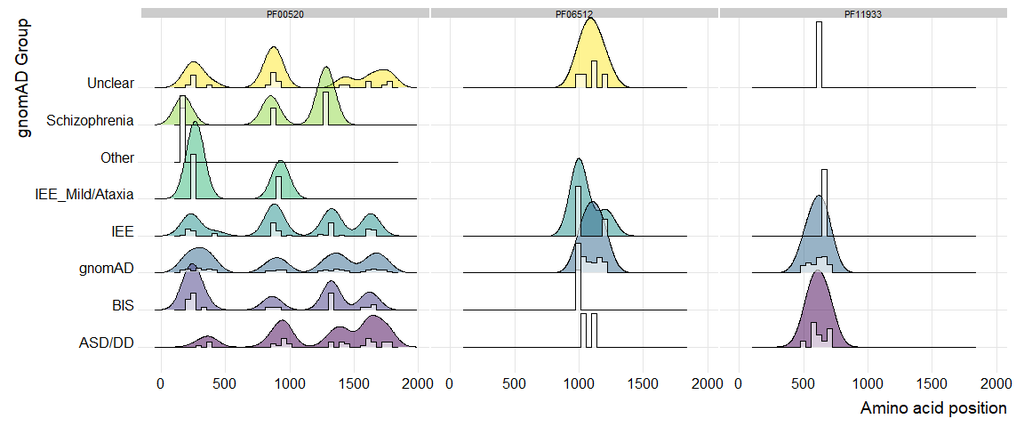

```r
d_pf1 %>% ggplot(aes(y = Group, x = Protein_position, fill = Group)) +
  geom_density_ridges(alpha = 0.5, bandwidth = 70) +
  geom_density_ridges(alpha=0.6, stat="binline", bins=40, fill = "white") +
  facet_grid(.~DOMAINS) +
  scale_fill_viridis(discrete = TRUE) +
  scale_color_viridis(discrete = TRUE) +
  theme_ridges() +
  theme(legend.position = "none",
        panel.spacing = unit(0.1, "lines"),
        strip.text.x = element_text(size = 8)) +
  xlab("Amino acid position") +
  ylab("gnomAD Group")
```

Well, there’s a problem in this visualization form. PF00520 domain has enough and even data about the gnomAD group, but the two others doesn’t. They contain only one or two items of information in the gnomAD group. So the first graph doesn’t have to be touched, but the other two needs to be modified a little more.

I tried to group the data according to protein domain information and drew each graph.

```r
p1 <- d_pf1 %>% filter(DOMAINS == "PF00520") %>%
  ggplot(aes(y = Group, x = Protein_position, fill = Group)) +
  geom_density_ridges(alpha = 0.5, bandwidth = 50) +
  geom_density_ridges(alpha=0.6, stat="binline", bins=40, fill = "white") +
  facet_grid(.~DOMAINS) +
  scale_fill_viridis(discrete = TRUE) +
  scale_color_viridis(discrete = TRUE) +
  theme_ridges() +
  theme(legend.position = "none",
        panel.spacing = unit(0.1, "lines"),
        strip.text.x = element_text(size = 8)) +
  xlab("") +
  ylab("gnomAD Group")
```

```r
p2 <- d_pf1 %>%
  filter(DOMAINS == "PF06512", Group %in% c("Unclear", "IEE", "gnomAD")) %>%
  ggplot(aes(y = Group, x = Protein_position, fill = Group)) +
  geom_density_ridges(alpha = 0.4, bandwidth = 10) +
  geom_density_ridges(alpha=0.6, stat="binline", bins=60, fill = "white") +
  facet_grid(.~DOMAINS) +
  scale_fill_manual(values=wes_palette(n=3, name="Darjeeling2")) +
  theme_ridges() +
  theme(legend.position = "none",
        panel.spacing = unit(0.1, "lines"),
        strip.text.x = element_text(size = 8)) +
  xlab("") +
  ylab("")
```

```r
p3 <- d_pf1 %>% filter(DOMAINS == "PF11933", Group %in% c("gnomAD", "ASD/DD")) %>%
  ggplot(aes(y = Group, x = Protein_position, fill = Group)) +
  geom_density_ridges(alpha = 0.4, bandwidth = 10) +
  geom_density_ridges(alpha=0.6, stat="binline", bins=40, fill = "white") +
  facet_grid(.~DOMAINS) +
  scale_fill_manual(values=wes_palette(n=3, name="Darjeeling2")) +
  theme_ridges() +
  theme(legend.position = "none",
        panel.spacing = unit(0.1, "lines"),
        strip.text.x = element_text(size = 8)) +
  xlab("Amino acid position") +
  ylab("")
```

Now, let’s put it all in one!

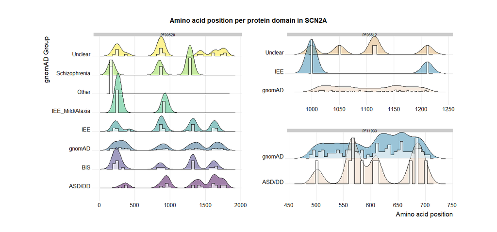

```r
library(cowplot)
right_row <- plot_grid(p2, p3, ncol = 1)
all_row <- plot_grid(p1, right_row, ncol = 2)
title <- ggdraw() +
  draw_label(
    "Amino acid position per protein domain in SCN2A",
    fontface = 'bold'
  )
plot_grid(title, all_row, ncol =1, rel_heights = c(0.1, 1))  +
  coord_fixed(ratio = 0.5)
```

## 4. Discussions

According to the graph, we can compare the amino acid position of patients to normal people(gnomAD). For example, IEE patients show high density of mutation in PF06512 protein position number 1,000 compared to the gnomAD people. Like this, as I mentioned above, knowing the distribution of amino acid positions makes it possible to know whether genetic variation affects disease, by comparing the position differences in patients with in normal people.

But there’s also limitation in this plotting processes. The amount of data is too small to indicate the exact distribution of amino acid locations. Since this density graph only displays genetic variation in very few patients, there must have been a great distortion in the value. Thus, if we could supplement the data further and modify the graph, it would be a highly utilized graph with the full benefit mentioned above.

## Final. Modifications

I modified the plot further based on the comments given by my classmates. The points in the comments were:

1. How about using the y label name “cds position”, instead of “GnomAD group”?
2. There are overlaps in the bar graph which makes it hard to see the graph clearly.
3. There’s no density plot in the “other” part in pf00520 plot.
4. Need more explanation about the abbreviations like IEE_mid, IEE.
5. How about using the same color between the same groups of different protein plots?

Based on these comments, I modified my plot to be more appropriate for visualizing.

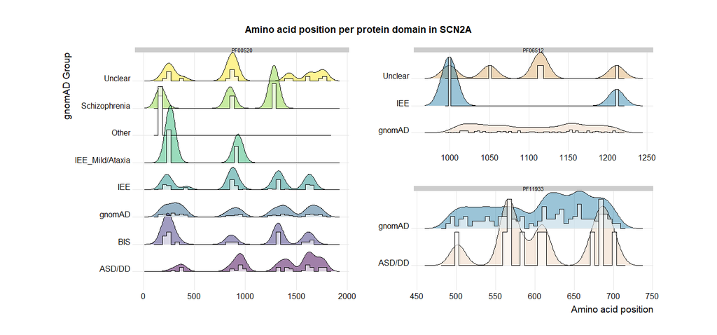

```r
library(cowplot)
right_row <- plot_grid(p2, p3, ncol = 1)
all_row <- plot_grid(p1, right_row, ncol = 2)
title <- ggdraw() +
  draw_label(
    "Amino acid position per protein domain in SCN2A",
    fontface = 'bold'
  )
plot_grid(title, all_row, ncol =1, rel_heights = c(0.1, 1))  +
  coord_fixed(ratio = 0.5)
```

First, look at the first comment.

**1. How about using the y label name “cds position”, instead of “GnomAD group”?**

I think that this classmate confused a little of the interpretation of the graph. The y label doesn’t include information about cds position. The y label compares different groups of people like gnomAD people(normal people), people with disorders like schizophrenia or ASD, etc. So, I think the name “gnomAD group” is more appropriate than “cds position” for the y label in this plot.

**2. There are overlaps in the bar graph which makes it hard to see the graph clearly.**

I also thought this problem needs some improvements. I’ll check the other comments first.

**3. There’s no density plot in the “other” part in pf00520 plot.**

The main reason for this problem is that there’s only one data in the “Other” group. This makes a abnormal high bar plot in the plot compared to the other datum. So, I think the “Other” data should be converged into other groups.

```r
table(d_pf1$Group)
```

```
         ASD/DD             BIS          gnomAD             IEE IEE_Mild/Ataxia
             50              26             647              83               3
          Other   Schizophrenia         Unclear
              1               4              27
```

The name “Other” makes it hard for us to know where group is the data included. So, I think the “Other” data should be included into “Unclear” group. Besides, I think the “IEE_Mild” group can also be converged into the “IEE” group together. So I merged them too.

```r
d_pf1$Group[grepl("Other", d_pf1$Group)] <- "Unclear"
d_pf1$Group[grepl("IEE_Mild/Ataxia", d_pf1$Group)] <- "IEE"
```

Now, let’s check whether the data is modified well.

```r
table(d_pf1$Group)
```

```
       ASD/DD           BIS        gnomAD           IEE Schizophrenia       Unclear
           50            26           647            86             4            28
```

```r
p1 <- d_pf1 %>% filter(DOMAINS == "PF00520") %>%
  ggplot(aes(y = Group, x = Protein_position, fill = Group)) +
  geom_density_ridges(alpha = 0.5, bandwidth = 50) +
  geom_density_ridges(alpha=0.6, stat="binline", bins=40, fill = "white") +
  facet_grid(.~DOMAINS) +
  scale_fill_viridis(discrete = TRUE) +
  scale_color_viridis(discrete = TRUE) +
  theme_ridges() +
  theme(legend.position = "none",
        panel.spacing = unit(0.1, "lines"),
        strip.text.x = element_text(size = 8)) +
  xlab("") +
  ylab("gnomAD Group")
```

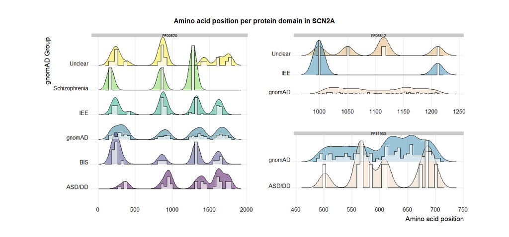

```r
library(cowplot)
right_row <- plot_grid(p2, p3, ncol = 1)
all_row <- plot_grid(p1, right_row, ncol = 2)
title <- ggdraw() +
  draw_label(
    "Amino acid position per protein domain in SCN2A",
    fontface = 'bold'
  )
plot_grid(title, all_row, ncol =1, rel_heights = c(0.1, 1))  +
  coord_fixed(ratio = 0.5)
```

**4. Need more explanation about the abbreviations like IEE_mid, IEE.**

I don’t think this comment is appropriate for reviewing the plot. I don’t think I should even add an explanation about the abbreviation as I draw a plot. But, to add an explanation about the IEE for now, it is as follows.

Idiopathic eosinophilic esophagitis (IEE) is a chronic-inflammatory disorder of the esophagus of unknown origin. The established cornerstone of diagnosis is a dense infiltration of the esophagus with eosinophils, but neither the precise pattern of inflammatory cell infiltration nor the mechanisms that likely contribute to induction and maintenance of the inflammatory response have been described.

**5. How about using the same color between the same groups of different protein plots?**

As I used the `plot_grid` function to merge three plots in one sheet, each of these graphs is separate, so this problem happens. I think the color of ‘PF00520’ plot is good for visualizing, so I modified the colors of two other plots based on this plot.

```r
p2 <- d_pf1 %>%
  filter(DOMAINS == "PF06512", Group %in% c("Unclear", "IEE", "gnomAD")) %>%
  ggplot(aes(y = Group, x = Protein_position, fill = Group)) +
  geom_density_ridges(alpha = 0.4, bandwidth = 10) +
  geom_density_ridges(alpha=0.6, stat="binline", bins=60, fill = "white") +
  facet_grid(.~DOMAINS) +
  theme_ridges() +
  scale_fill_manual(values = c("#064e94", "#048f75", "#f7f402")) +
  theme(legend.position = "none",
        panel.spacing = unit(0.1, "lines"),
        strip.text.x = element_text(size = 8)) +
  xlab("") +
  ylab("")
```

```r
p3 <- d_pf1 %>% filter(DOMAINS == "PF11933", Group %in% c("gnomAD", "ASD/DD")) %>%
  ggplot(aes(y = Group, x = Protein_position, fill = Group)) +
  geom_density_ridges(alpha = 0.4, bandwidth = 10) +
  geom_density_ridges(alpha=0.6, stat="binline", bins=40, fill = "white") +
  facet_grid(.~DOMAINS) +
  scale_fill_manual(values = c("#36086e", "#064e94")) +
  theme_ridges() +
  theme(legend.position = "none",
        panel.spacing = unit(0.1, "lines"),
        strip.text.x = element_text(size = 8)) +
  xlab("Amino acid position") +
  ylab("")
```

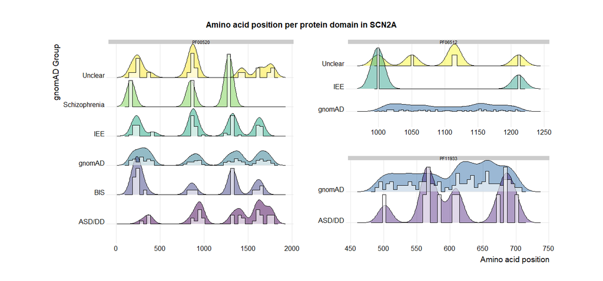

```r
library(cowplot)
right_row <- plot_grid(p2, p3, ncol = 1)
all_row <- plot_grid(p1, right_row, ncol = 2)
title <- ggdraw() +
  draw_label(
    "Amino acid position per protein domain in SCN2A",
    fontface = 'bold'
  )
plot_grid(title, all_row, ncol =1, rel_heights = c(0.1, 1))  +
  coord_fixed(ratio = 0.5)
```

Now, it’s the time for last comment:

**2. There are overlaps in the bar graph which makes it hard to see the graph clearly.**

There are three remarkable overlaps in the plot : “PF00520:Schizophrenia”, “PF06512:IEE”, “PF11933:ASD/DD”.

The reason for this overlap is that the size of the data is too small, exaggerating a specific amino acid position, and I think this is the limitation of this plot.

Anyway, to be more appropriate for visualizing,

```r
p1 <- d_pf1 %>% filter(DOMAINS == "PF00520") %>%
  ggplot(aes(y = Group, x = Protein_position, fill = Group)) +
  geom_density_ridges(alpha = 0.5, bandwidth = 50, scale = 1.5) +
  geom_density_ridges(alpha=0.6, stat="binline", bins=40, fill = "white", scale = 1) +
  facet_grid(.~DOMAINS) +
  scale_fill_viridis(discrete = TRUE) +
  scale_color_viridis(discrete = TRUE) +
  theme_ridges() +
  theme(legend.position = "none",
        panel.spacing = unit(0.1, "lines"),
        strip.text.x = element_text(size = 8)) +
  xlab("") +
  ylab("gnomAD Group")
```

```r
p2 <- d_pf1 %>%
  filter(DOMAINS == "PF06512", Group %in% c("Unclear", "IEE", "gnomAD")) %>%
  ggplot(aes(y = Group, x = Protein_position, fill = Group)) +
  geom_density_ridges(alpha = 0.4, bandwidth = 10, scale = 1.5) +
  geom_density_ridges(alpha=0.6, stat="binline", bins=60, fill = "white", scale = 1) +
  facet_grid(.~DOMAINS) +
  theme_ridges() +
  scale_fill_manual(values = c("#064e94", "#048f75", "#f7f402")) +
  theme(legend.position = "none",
        panel.spacing = unit(0.1, "lines"),
        strip.text.x = element_text(size = 8)) +
  xlab("") +
  ylab("")
```

```r
p3 <- d_pf1 %>% filter(DOMAINS == "PF11933", Group %in% c("gnomAD", "ASD/DD")) %>%
  ggplot(aes(y = Group, x = Protein_position, fill = Group)) +
  geom_density_ridges(alpha = 0.4, bandwidth = 10, scale = 1.5) +
  geom_density_ridges(alpha=0.6, stat="binline", bins=40, fill = "white", scale = 1) +
  facet_grid(.~DOMAINS) +
  scale_fill_manual(values = c("#36086e", "#064e94")) +
  theme_ridges() +
  theme(legend.position = "none",
        panel.spacing = unit(0.1, "lines"),
        strip.text.x = element_text(size = 8)) +
  xlab("Amino acid position") +
  ylab("")
```

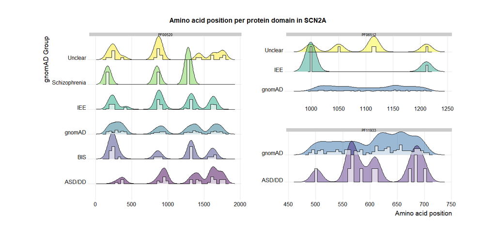

```r
library(cowplot)
right_row <- plot_grid(p2, p3, ncol = 1)
all_row <- plot_grid(p1, right_row, ncol = 2)
title <- ggdraw() +
  draw_label(
    "Amino acid position per protein domain in SCN2A",
    fontface = 'bold'
  )
plot_grid(title, all_row, ncol =1, rel_heights = c(0.1, 1))  +
  coord_fixed(ratio = 0.5)
```

By adjusting the scale, the overlap has a little supplemented.